# **Introdução ao R**

## 5.2 Matrizes

Uma matriz $A=(a_{ij})$ também é uma estrutura que pode ser utilizada para armazenar dados. Uma matriz é representada no R com o uso da função `matrix()`. Por exemplo, suponha que seja necessário organizar a sequência `1:24` na forma de uma matriz $4\times 6$. Para representá-la no R, basta proceder tal como abaixo:

```r
# Exemplo
mat.A <- matrix(1:24,nrow=4,ncol=6) # organizando os dados por colunas
mat.A
##      [,1] [,2] [,3] [,4] [,5] [,6]
## [1,]    1    5    9   13   17   21
## [2,]    2    6   10   14   18   22
## [3,]    3    7   11   15   19   23
## [4,]    4    8   12   16   20   24
mat.B <- matrix(1:24,4,6,byrow=TRUE) # organizando os dados por linhas
mat.B
##      [,1] [,2] [,3] [,4] [,5] [,6]
## [1,]    1    2    3    4    5    6
## [2,]    7    8    9   10   11   12
## [3,]   13   14   15   16   17   18
## [4,]   19   20   21   22   23   24
mat.C <- t(mat.A) # retorna a transporta da matriz mat.A
colnames(mat.C) <- c("SP","RJ","MG","ES")
rownames(mat.C) <- c("Jan","Fev","Mar","Abr","Mai", "Jun")
mat.C
##     SP RJ MG ES
## Jan  1  2  3  4
## Fev  5  6  7  8
## Mar  9 10 11 12
## Abr 13 14 15 16
## Mai 17 18 19 20
## Jun 21 22 23 24
```

Tal como no caso de vetores, também é possível selecionar os valores de certas entradas de uma matriz. O procedimento é bem semelhante, basta usar os possíveis valores para os índices $i$ e $j$ que indexam a matriz. Vejamos os seguintes exemplos:

```r
# Exemplos
mat.D <- matrix(25:48,4,6,byrow=TRUE)
mat.D
##      [,1] [,2] [,3] [,4] [,5] [,6]
## [1,]   25   26   27   28   29   30
## [2,]   31   32   33   34   35   36
## [3,]   37   38   39   40   41   42
## [4,]   43   44   45   46   47   48
mat.D[1:3,] # seleciona as 3 primeiras linhas
##      [,1] [,2] [,3] [,4] [,5] [,6]
## [1,]   25   26   27   28   29   30
## [2,]   31   32   33   34   35   36
## [3,]   37   38   39   40   41   42
mat.D[,c(4,6)] # seleciona as colunas 4 e 6
##      [,1] [,2]
## [1,]   28   30
## [2,]   34   36
## [3,]   40   42
## [4,]   46   48
mat.D[1:3,c(4,6)] # seleciona as entradas das 3 primeiras linhas que se encontram nas colunas 4 e 6
##      [,1] [,2]
## [1,]   28   30
## [2,]   34   36
## [3,]   40   42
```

Estude também os seguintes exemplos:

```r
# Exemplos
mat.A1 <- matrix(c(1,4,-2,5,3,-6),nrow=2,ncol=3)
mat.A1
##      [,1] [,2] [,3]
## [1,]    1   -2    3
## [2,]    4    5   -6
mat.A2 <- matrix(c(2,0,3,8,-4,1),nrow=3,ncol=2)
mat.A2
##      [,1] [,2]
## [1,]    2    8
## [2,]    0   -4
## [3,]    3    1
#
# operações com matrizes
#
3*mat.A1 # multiplicação por escalar
##      [,1] [,2] [,3]
## [1,]    3   -6    9
## [2,]   12   15  -18
mat.A3 <- t(mat.A2) # transporta da matriz mat.A2
mat.A3
##      [,1] [,2] [,3]
## [1,]    2    0    3
## [2,]    8   -4    1
mat.A1+mat.A3 # adição matricial
##      [,1] [,2] [,3]
## [1,]    3   -2    6
## [2,]   12    1   -5
mat.A1*mat.A3 # multiplicação matricial componente a componente
##      [,1] [,2] [,3]
## [1,]    2    0    9
## [2,]   32  -20   -6
mat.A4 <- mat.A1%*%mat.A2 # multiplicação matricial
mat.A4
##      [,1] [,2]
## [1,]   11   19
## [2,]  -10    6
det(mat.A4) # determinante da matriz quadrada mat.A4
## [1] 256
mat.A5 <- diag(c(2.03,3.14,1.41,-3.47)) # retorna uma matriz diagonal
#------------------------------------------------------------------------
#
# NOTE QUE O R ENTENDE VETORES SEMPRE COMO VETORES COLUNAS!!!
#
#------------------------------------------------------------------------
mat.A6 <- mat.A1%*%c(3,-2,1);mat.A6
##      [,1]
## [1,]   10
## [2,]   -4
mat.A7 <- c(3,-2,1)%*%mat.A1;mat.A7
## Error in c(3, -2, 1) %*% mat.A1: argumentos não compatíveis
## Error in eval(expr, envir, enclos): objeto 'mat.A7' não encontrado
mat.A8 <- t(c(3,-2))%*%mat.A1;mat.A8
##      [,1] [,2] [,3]
## [1,]   -5  -16   21
#------------------------------------------------------------------------
```

## 5.3 Data frames

Considere o seguinte conjunto de dados ($\mbox{IMC}=\mbox{Peso}/\mbox{Altura}^{2}$):

| ID | Idade | Sexo | Altura | Peso | IMC |
| --- | --- | --- | --- | --- | --- |
| 001 | 26 | M | 1.71 | 70 | 23.94 |
| 002 | 35 | F | 1.72 | 83 | 28.06 |
| 003 | 41 | M | 1.83 | 63 | 18.81 |
| 004 | 28 | M | 1.94 | 77 | 20.46 |
| 005 | 23 | F | 1.65 | 70 | 25.71 |
| 006 | 30 | M | 1.68 | 90 | 31.89 |
| 007 | 48 | F | 1.79 | 89 | 27.78 |

Este conjunto de dados pode ser representado no R com o uso da função `data.frame()`. Vejamos o seguinte exemplo:

```r
# Exemplo
id <- 1:7
idade <- c(26,35,41,28,23,30,48)
sexo <- c("M","F","M","M","F","M","F")
altura <- c(1.71,1.72,1.83,1.94,1.65,1.68,1.79)
peso <- c(70,83,63,77,70,90,89)
imc <- peso/(altura^2)
imc.r <- round(imc,2)
df.dados <- data.frame(id,idade,sexo,altura,peso,imc.r)
df.dados
##   id idade sexo altura peso imc.r
## 1  1    26    M   1.71   70 23.94
## 2  2    35    F   1.72   83 28.06
## 3  3    41    M   1.83   63 18.81
## 4  4    28    M   1.94   77 20.46
## 5  5    23    F   1.65   70 25.71
## 6  6    30    M   1.68   90 31.89
## 7  7    48    F   1.79   89 27.78
summary(df.dados) # retorna algumas estatísticas para as variáveis do conjunto de dados
##        id          idade    sexo      altura           peso
##  Min.   :1.0   Min.   :23   F:3   Min.   :1.650   Min.   :63.00
##  1st Qu.:2.5   1st Qu.:27   M:4   1st Qu.:1.695   1st Qu.:70.00
##  Median :4.0   Median :30         Median :1.720   Median :77.00
##  Mean   :4.0   Mean   :33         Mean   :1.760   Mean   :77.43
##  3rd Qu.:5.5   3rd Qu.:38         3rd Qu.:1.810   3rd Qu.:86.00
##  Max.   :7.0   Max.   :48         Max.   :1.940   Max.   :90.00
##      imc.r
##  Min.   :18.81
##  1st Qu.:22.20
##  Median :25.71
##  Mean   :25.24
##  3rd Qu.:27.92
##  Max.   :31.89
dim(df.dados) # retorna a dimensão do conjunto de dados (7 unidades e 6 variáveis)
## [1] 7 6
```

Alternativamente, é possível usar a função `matrix()`.

```r
# Exemplo
id <- 1:7
idade <- c(26,35,41,28,23,30,48)
sexo <- c("M","F","M","M","F","M","F")
sexo
## [1] "M" "F" "M" "M" "F" "M" "F"
sexo.f <- factor(sexo) # converte o vetor de caracteres sexo em fator com 2 níveis
sexo.f
## [1] M F M M F M F
## Levels: F M
altura <- c(1.71,1.72,1.83,1.94,1.65,1.68,1.79)
peso <- c(70,83,63,77,70,90,89)
imc <- peso/(altura^2)
imc.r <- round(imc,2)
mat.dados <- matrix(c(id,idade,sexo.f,altura,peso,imc.r),nrow=7,ncol=6)
rownames(mat.dados) <- 1:7
colnames(mat.dados) <- c("id","idade","sexo","altura","peso","imc.r")
mat.dados
##   id idade sexo altura peso imc.r
## 1  1    26    2   1.71   70 23.94
## 2  2    35    1   1.72   83 28.06
## 3  3    41    2   1.83   63 18.81
## 4  4    28    2   1.94   77 20.46
## 5  5    23    1   1.65   70 25.71
## 6  6    30    2   1.68   90 31.89
## 7  7    48    1   1.79   89 27.78
summary(mat.dados) # retorna algumas estatísticas para as variáveis do conjunto de dados
##        id          idade         sexo           altura
##  Min.   :1.0   Min.   :23   Min.   :1.000   Min.   :1.650
##  1st Qu.:2.5   1st Qu.:27   1st Qu.:1.000   1st Qu.:1.695
##  Median :4.0   Median :30   Median :2.000   Median :1.720
##  Mean   :4.0   Mean   :33   Mean   :1.571   Mean   :1.760
##  3rd Qu.:5.5   3rd Qu.:38   3rd Qu.:2.000   3rd Qu.:1.810
##  Max.   :7.0   Max.   :48   Max.   :2.000   Max.   :1.940
##       peso           imc.r
##  Min.   :63.00   Min.   :18.81
##  1st Qu.:70.00   1st Qu.:22.20
##  Median :77.00   Median :25.71
##  Mean   :77.43   Mean   :25.24
##  3rd Qu.:86.00   3rd Qu.:27.92
##  Max.   :90.00   Max.   :31.89
dim(mat.dados) # retorna a dimensão do conjunto de dados (7 unidades e 6 variáveis)
## [1] 7 6
```

Vejamos agora como selecionar dados de um data frame:

```r
# Exemplo
id <- 1:7
idade <- c(26,35,41,28,23,30,48)
sexo <- c("M","F","M","M","F","M","F")
altura <- c(1.71,1.72,1.83,1.94,1.65,1.68,1.79)
peso <- c(70,83,63,77,70,90,89)
imc <- peso/(altura^2)
imc.r <- round(imc,2)
df.dados <- data.frame(id,idade,sexo,altura,peso,imc.r)
df.dados
##   id idade sexo altura peso imc.r
## 1  1    26    M   1.71   70 23.94
## 2  2    35    F   1.72   83 28.06
## 3  3    41    M   1.83   63 18.81
## 4  4    28    M   1.94   77 20.46
## 5  5    23    F   1.65   70 25.71
## 6  6    30    M   1.68   90 31.89
## 7  7    48    F   1.79   89 27.78
df.dados$sexo;levels(df.dados$sexo)
## [1] M F M M F M F
## Levels: F M
## [1] "F" "M"
df.dados[,c(3,2,4)]
##   sexo idade altura
## 1    M    26   1.71
## 2    F    35   1.72
## 3    M    41   1.83
## 4    M    28   1.94
## 5    F    23   1.65
## 6    M    30   1.68
## 7    F    48   1.79
subset(df.dados,select=c("sexo","idade","altura"))
##   sexo idade altura
## 1    M    26   1.71
## 2    F    35   1.72
## 3    M    41   1.83
## 4    M    28   1.94
## 5    F    23   1.65
## 6    M    30   1.68
## 7    F    48   1.79
subset(df.dados,subset=(idade>30)&(idade<=41))
##   id idade sexo altura peso imc.r
## 2  2    35    F   1.72   83 28.06
## 3  3    41    M   1.83   63 18.81
subset(df.dados,subset=sexo==levels(df.dados$sexo)[1])
##   id idade sexo altura peso imc.r
## 2  2    35    F   1.72   83 28.06
## 5  5    23    F   1.65   70 25.71
## 7  7    48    F   1.79   89 27.78
```

## 5.4 Listas

Uma lista é uma estrutura heterogênea para armazenar dados. Vejamos um exemplo simples e também como selecionar dados de uma lista:

```r
# Exemplo
y1 <- 1:3
y2 <- c(1.55,pi,sin(pi/3),82,sqrt(3),exp(1))
y3 <- c("Ana","Maria","Pedro","Paulo")
y4 <- factor(c("F","F","M","M"))
lista.dados <- list(var1=y1,var2=y2,var3=y3,var4=y4)
lista.dados
## $var1
## [1] 1 2 3
##
## $var2
## [1]  1.5500000  3.1415927  0.8660254 82.0000000  1.7320508  2.7182818
##
## $var3
## [1] "Ana"   "Maria" "Pedro" "Paulo"
##
## $var4
## [1] F F M M
## Levels: F M
lista.dados$var1
## [1] 1 2 3
lista.dados$var2
## [1]  1.5500000  3.1415927  0.8660254 82.0000000  1.7320508  2.7182818
lista.dados$var3
## [1] "Ana"   "Maria" "Pedro" "Paulo"
lista.dados$var4
## [1] F F M M
## Levels: F M
```

[Voltar ao topo](http://www.maurocampos.com/cursos/intror/intror.html)

# 6 Definindo uma nova função

No R é possível definir uma nova função. Suponha que na sua aplicação de interesse existe uma função chamada **Retorno** que é definida como

$$f(x|\alpha,\beta)=\frac{\alpha}{1+\beta x^{2}}$$
onde $x$ é a variável de entrada e $\alpha,\beta$ são parâmetros. No R a função **Retorno** pode ser definida tal como segue:

```r
# Exemplo
f.retorno <- function(x,par1,par2){
  out1 <- (par1)/(1+par2*x^(2))
  out2 <- "retorno"
  out <- list(valor=out1,alpha.par=par1,beta.par=par2,nome=out2)
  return(out)
}
aux <- f.retorno(x=3.4,par1=1,par2=2)
aux
## $valor
## [1] 0.04145937
##
## $alpha.par
## [1] 1
##
## $beta.par
## [1] 2
##
## $nome
## [1] "retorno"
aux$valor
## [1] 0.04145937
aux$alpha.par
## [1] 1
aux$beta.par
## [1] 2
aux$nome
## [1] "retorno"
```

[Voltar ao topo](http://www.maurocampos.com/cursos/intror/intror.html)

# 7 Gráficos com plot()

A função `plot()` pode ser usada para fazer gráficos. Vejamos um exemplo simples que apresenta o gráfico da função $f(x)=x^{2}$ para $x\in[-5,5]$.

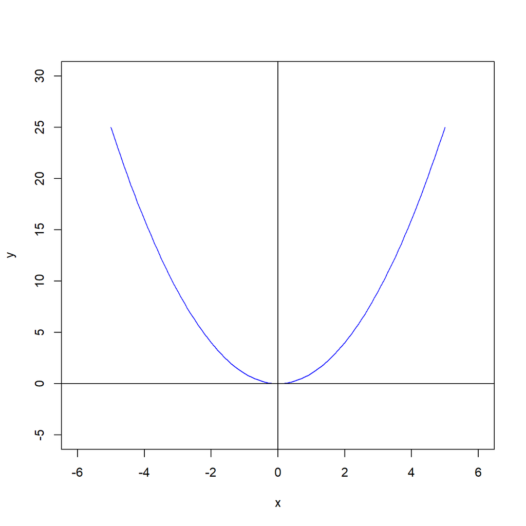

**Fig.: Gráfico da função** $x^2$.

```r
x <- seq(-5,5,0.1)
y <- x^(2)
plot(x,y,type="l",xlim=c(-6,6),ylim=c(-5,30),xlab="x",ylab="y",col="blue")
abline(h=0);abline(v=0)
```

[Voltar ao topo](http://www.maurocampos.com/cursos/intror/intror.html)

# 8 Gráficos com curve()

A função `curve()` também pode ser usada para fazer gráficos. Vejamos um exemplo simples que apresenta o plot simultâneo das funções $f(x)=x^{2}-2$ e $g(x)=x^{3}-3x$ para $x\in[-2,2]$.

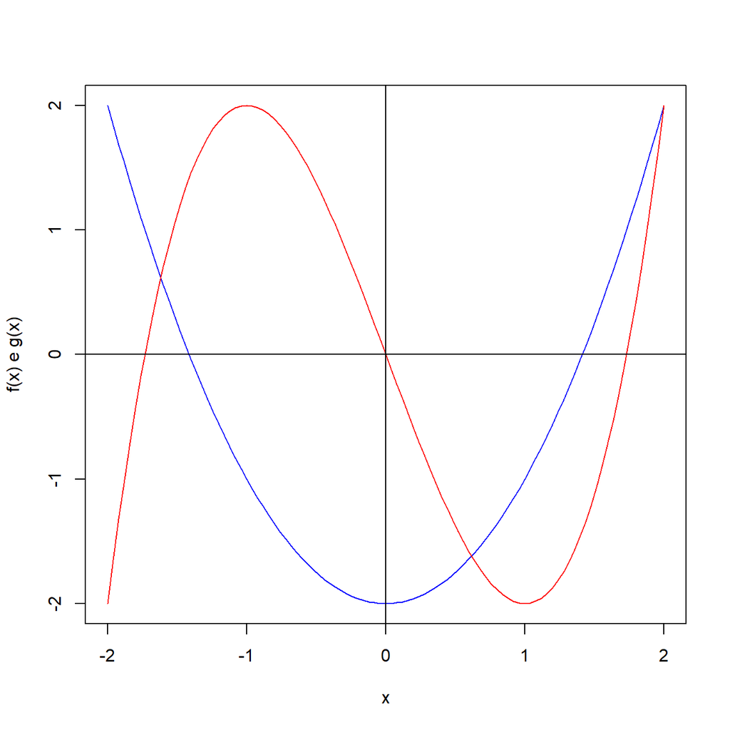

**Fig.: Gráficos simultâneos**. $f(x)=x^{2}-2$ (**em azul**) **e** $g(x)=x^{3}-3x$ (**em vermelho**).

```r
curve(x^(2)-2,-2,2,xlab="x",ylab="f(x) e g(x)",col="blue")
curve(x^(3)-3*x,-2,2,col="red",add=TRUE)
abline(h=0);abline(v=0)
```

[Voltar ao topo](http://www.maurocampos.com/cursos/intror/intror.html)

# 9 Múltiplos gráficos

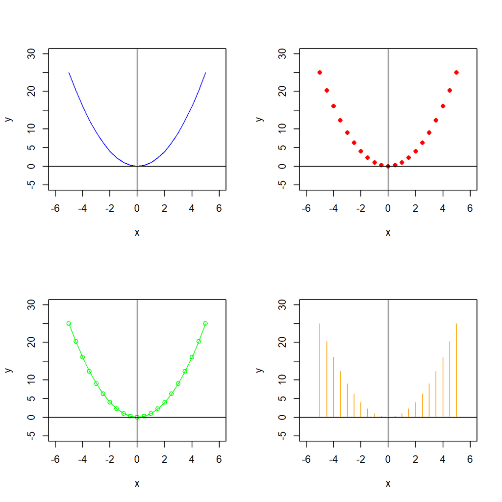

**Fig.: Diferentes gráficos da função** $x^2$.

```r
x <- seq(-5,5,0.5)
y <- x^(2)
par(mfrow=c(2,2))
plot(x,y,type="l",xlim=c(-6,6),ylim=c(-5,30),xlab="x",ylab="y",col="blue");abline(h=0);abline(v=0)
plot(x,y,type="p",xlim=c(-6,6),ylim=c(-5,30),xlab="x",ylab="y",pch=16,col="red");abline(h=0);abline(v=0)
plot(x,y,type="o",xlim=c(-6,6),ylim=c(-5,30),xlab="x",ylab="y",col="green");abline(h=0);abline(v=0)
plot(x,y,type="h",xlim=c(-6,6),ylim=c(-5,30),xlab="x",ylab="y",col="orange");abline(h=0);abline(v=0)
```

```r
dev.off()
## null device
##           1
```

[Voltar ao topo](http://www.maurocampos.com/cursos/intror/intror.html)

# 10 Programando em R

R é também uma linguagem de programação, ou seja, é possível desenvolver códigos em R pra resolver problemas. Como qualquer outra linguagem de programação, R possui estruturas de decisão condicional e loops. Vejamos:

```
if(condição){lista de comandos}
if(condição){lista 1 de comandos} else {lista 2 de comandos}
for(var in seq){lista de comandos}
while(condição){lista de comandos}
repeat{lista de comandos;if(condição){break}}
```

## 10.1 if

```r
x <- 1 # x armazena o valor 1
p <- runif(1,0,1) # p recebe um número aleatório entre 0 e 1
p
## [1] 0.7866644
if(p < 1/2){x <- 10}
x
## [1] 1
```

## 10.2 if/else

```r
x <- 0
p <- runif(1,0,1) # p recebe um número aleatório entre 0 e 1
p
## [1] 0.8621572
if(p < 1/3){
  x <- 10;print("Ganhou 10")
} else {
  x <- -10;print("Perdeu 10")
}
## [1] "Perdeu 10"
```

## 10.3 for

```r
x <- NULL
for(i in 1:10){
  x[i] <- i*9
  print(x)
}
## [1] 9
## [1]  9 18
## [1]  9 18 27
## [1]  9 18 27 36
## [1]  9 18 27 36 45
## [1]  9 18 27 36 45 54
## [1]  9 18 27 36 45 54 63
## [1]  9 18 27 36 45 54 63 72
## [1]  9 18 27 36 45 54 63 72 81
##  [1]  9 18 27 36 45 54 63 72 81 90
x
##  [1]  9 18 27 36 45 54 63 72 81 90
```

## 10.4 while

```r
x <- rep(NA,5)
i <- 1
while(i<6){
  x[i] <- i^2
  print(x)
  i <- i+1
}
## [1]  1 NA NA NA NA
## [1]  1  4 NA NA NA
## [1]  1  4  9 NA NA
## [1]  1  4  9 16 NA
## [1]  1  4  9 16 25
x
## [1]  1  4  9 16 25
```

```r
x <- NA # x possui um valor não disponível (NA: not available)
is.na(x) # retorna TRUE se x possui um valor NA
## [1] TRUE
i <- 1
while(i<6){
  x <- i^2
  print(x)
  i <- i+1
}
## [1] 1
## [1] 4
## [1] 9
## [1] 16
## [1] 25
x
## [1] 25
is.na(x)
## [1] FALSE
```

## 10.5 repeat

```r
x <- NA
is.na(x)
## [1] TRUE
i <- 1
repeat{
  x <- i^2
  print(x)
  i <- i+1
  if(i==6){break}
}
## [1] 1
## [1] 4
## [1] 9
## [1] 16
## [1] 25
x
## [1] 25
is.na(x)
## [1] FALSE
```

[Voltar ao topo](http://www.maurocampos.com/cursos/intror/intror.html)

# Referências

Dalgaard, P. 2002. *Introductory Statistics with R*. New York, Springer-Verlag.

Venables, W., D. Smith, and The R Core Team. 2017. “An Introduction to R, Version 3.4.1.” *R Documentation/Manuals*, June. The R Development Core Team, p 1–99. https://cran.r-project.org/manuals.html.